# Aides Drug

YURIPSA PALACIOS!

NOVEMBER 21ST, 2019

# 1 Introduction

A new preventative aides (abacavirinol) is under test in clinical trials. Analyze the effectiveness of this drug across the board. Consider population subgroups by gender, drug use, and sexual orientation. Finish this!

# 2 Methods

In everyone one of the tests we will be looking into if there is a relationship with the categorical variable and the null hypothesis. we will be using a bar graph, a cross tab table and a chi-square test.

QUESTION 1: Is the vaccine affective for the whole population?

H0:The vaccine is not effective. HA: The vaccine affects whether or not one contracts AIDS.

QUESTION 2: Does the vaccine prove affective for women?

H0: The vaccine does not prove effective for women. HA: The vaccine affects whether or not a women contracts AIDS.

QUESTION 3: Does the vaccine prove effective for men?

H0: The vaccine does not prove to be effective for men. HA: The vaccine affects whether or not men contracts AIDS.

QUESTION 4: Is the vaccine affective for drug users?

H0: The vaccine is not effetcive for drug users. HA: The vaccine affects whether or not drug users contracts AIDS.

QUESTION 5: Is the vaccine affective for LGBTQ people?

H0: The vaccine is not effective in LGBTQ people. HA: The vaccine affects whether or not LGBTQ people contracts AIDS.

# 3 Results

## 3.1 Descriptive Results

### 3.1.1 Graphical Descriptive Results

QUESTION 1

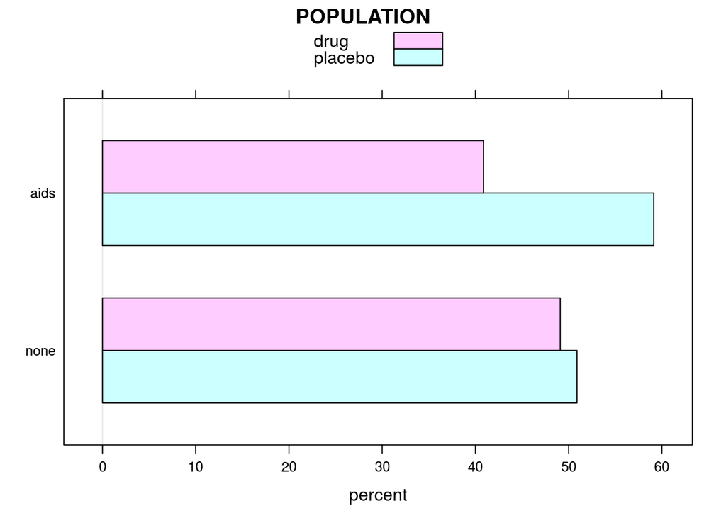

```r
barchartGC(~infected+treatment, data= avast, main = 'POPULATION', type = 'percent', horizontal= TRUE)
```

Based on the data in the above bar chart, it appears that the drug was more effective than the placebo. It appears that people that dont have AIDS have a very similar result between the drug and the placebo. It appears that we would reject the null hypothesis for this bar graph test.

QUESTION 2

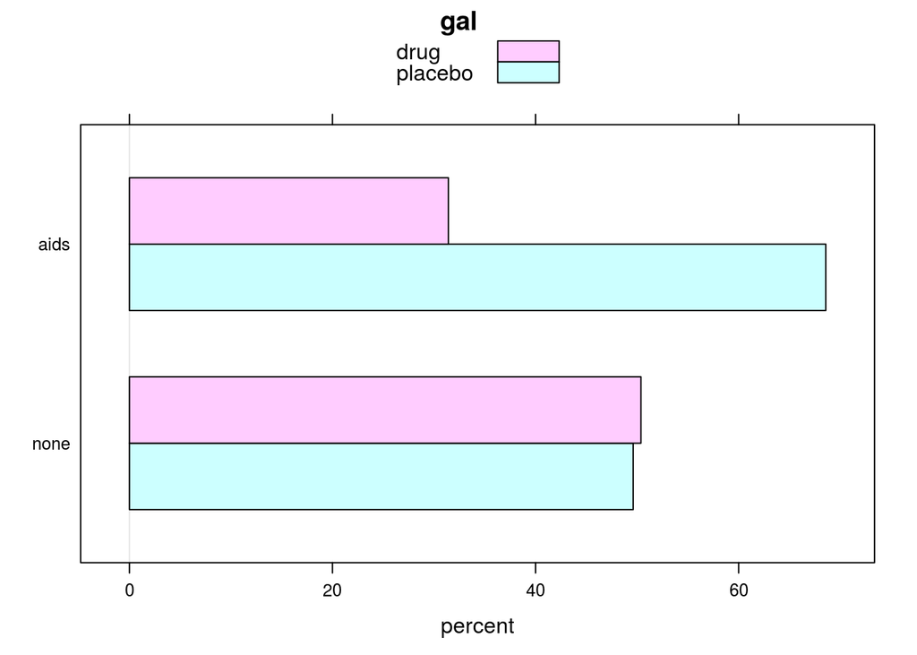

```r
barchartGC(~infected+treatment, main = 'gal', type = 'percent',  data=filter(avast, sex == 'gal'), horizontal = TRUE)
```

Based on the data in the above bar chart, it appears that the drug was more affective than the placebo for women. It appears that women that dont have AIDS have a very similar result between the drug and the placebo. It appears that we would reject the null hypothesis for this bar graph test.

QUESTION 3

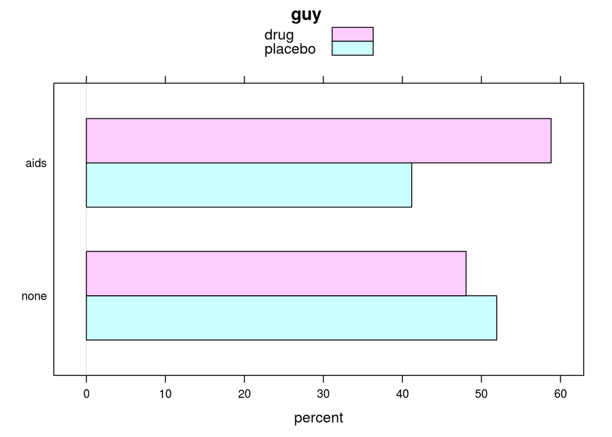

```r
barchartGC(~infected+treatment, main = 'guy', type = 'percent',  data=filter(avast, sex == 'guy'), horizontal = TRUE)
```

QUESTION 4

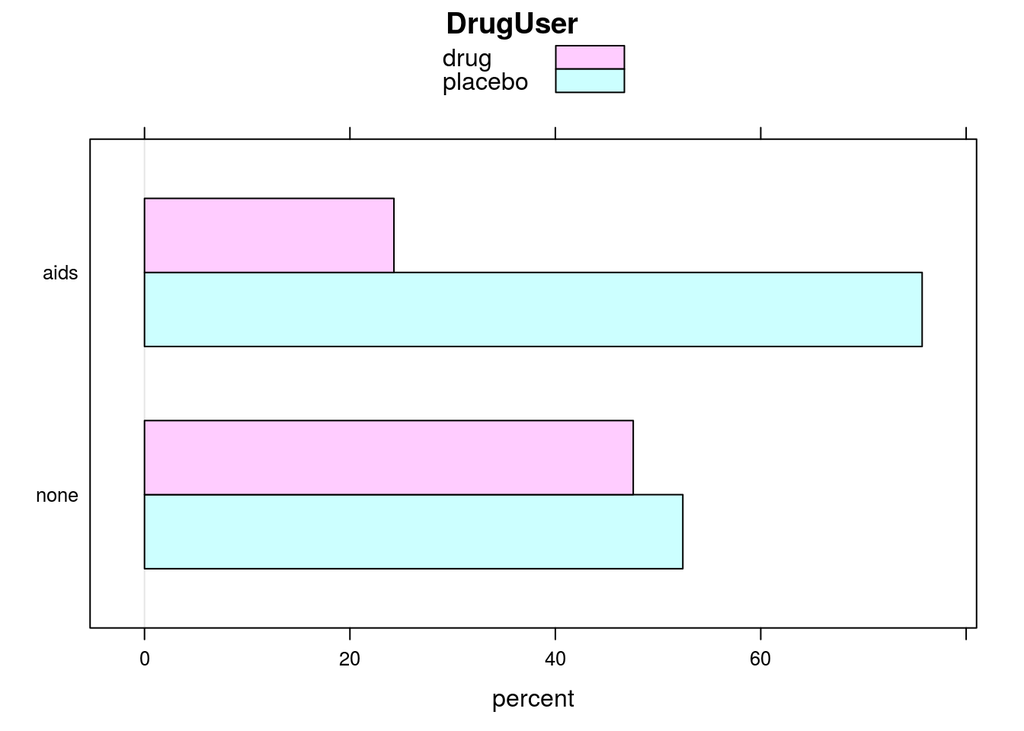

```r
barchartGC(~ infected+treatment, , main = 'DrugUser', type = 'percent',  data=filter(avast, DrugUser == 'yes'), horizontal = TRUE)
```

Based on the data in the above bar chart, it appears that the drug was much more effective than the placebo for Drug users. It appears that drug users that dont have AIDS have a very similar result between the drug and the placebo. It appears that we would reject the null hypothesis for this bar graph test.

QUESTION 5

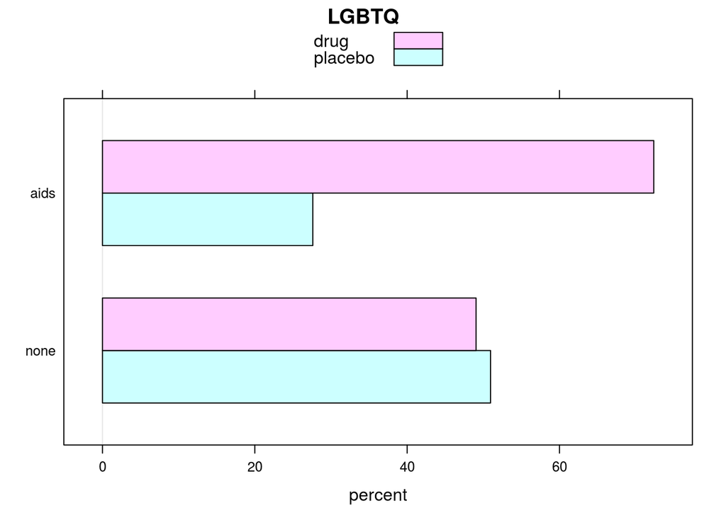

```r
barchartGC(~infected+treatment, , main = 'LGBTQ', type = 'percent',  data=filter(avast, LGBTQ == 'gay'), horizontal = TRUE)
```

### 3.1.2 Numerical Descriptive Results

QUESTION 1

```r
tab1 = xtabs(~infected+treatment, data=filter(avast))
rowPerc(tab1)
```

```
##         treatment
## infected   drug placebo  Total
##     aids  40.87   59.13 100.00
##     none  49.10   50.90 100.00
```

It appears that for those that have AIDS, have a higher chance of prevention with the drug than the placebo. The people who dont have AIDS show no significant change in effectivness between the drug and the placebo.

QUESTION 2

```r
tab2 = xtabs(~infected+treatment, data=filter(avast, sex== 'gal'))
rowPerc(tab2)
```

```
##         treatment
## infected   drug placebo  Total
##     aids  31.42   68.58 100.00
##     none  50.38   49.62 100.00
```

It appears that for the women that have AIDS,they have a higher chance of prevention with the drug than the placebo. The women who dont have AIDS show no significant change in effectivness between the drug and the placebo.

QUESTION 3

```r
tab3 = xtabs(~infected+treatment, data=filter(avast, sex== 'guy'))
rowPerc(tab3)
```

```
##         treatment
## infected   drug placebo  Total
##     aids  58.82   41.18 100.00
##     none  48.06   51.94 100.00
```

It appears that for guys, that the vaccine makes them more susceptable to contracting AIDS then with the placebo. The guys who dont have AIDS show no significant change in effectivness between the drug and the placebo.

QUESTION 4

```r
tab4 = xtabs(~infected+treatment, data=filter(avast, DrugUser== 'yes'))
rowPerc(tab4)
```

```
##         treatment
## infected   drug placebo  Total
##     aids  24.29   75.71 100.00
##     none  47.59   52.41 100.00
```

It appears that for the Drug users that have AIDS, they have a higher chance of prevention with the drug than the placebo. The Drug users who dont have AIDS show no significant change in effectivness between the drug and the placebo.

QUESTION 5

```r
tab5 = xtabs(~infected+treatment, data=filter(avast, LGBTQ== 'gay'))
rowPerc(tab5)
```

```
##         treatment
## infected   drug placebo  Total
##     aids  72.38   27.62 100.00
##     none  49.05   50.95 100.00
```

It appears that for LGBTQ people, the vaccine makes them more susceptable to contracting AIDS then with the placebo. The LGBTQ people who dont have AIDS show no significant change in effectivness between the drug and the placebo.

## 3.2 Inferential Results

QUESTION 1

```r
chisqtestGC(tab1)
```

```
## Pearson's Chi-squared test with Yates' continuity correction
##
## Observed Counts:
##         treatment
## infected  drug placebo
##     aids   423     612
##     none 10168   10540
##
## Counts Expected by Null:
##         treatment
## infected     drug  placebo
##     aids   504.15   530.85
##     none 10086.85 10621.15
##
## Contributions to the chi-square statistic:
##         treatment
## infected  drug placebo
##     aids 13.06   12.40
##     none  0.65    0.62
##
##
## Chi-Square Statistic = 26.4104
## Degrees of Freedom of the table = 1
## P-Value = 0
```

The p-value for the Chisq test is 0 < 0.05 so we reject the null hypothesis and conclude we have the evidence to support the contention that the vaccine for people with AIDS is effective.

QUESTION 2

```r
chisqtestGC(tab2)
```

```
## Pearson's Chi-squared test with Yates' continuity correction
##
## Observed Counts:
##         treatment
## infected drug placebo
##     aids  213     465
##     none 4684    4613
##
## Counts Expected by Null:
##         treatment
## infected    drug placebo
##     aids  332.85  345.15
##     none 4564.15 4732.85
##
## Contributions to the chi-square statistic:
##         treatment
## infected  drug placebo
##     aids 43.15   41.62
##     none  3.15    3.03
##
##
## Chi-Square Statistic = 90.1943
## Degrees of Freedom of the table = 1
## P-Value = 0
```

The p-value for the Chisq test is 0 < 0.05 so we reject the null hypothesis and conclude we have the evidence to support the contention that the vaccine for women with AIDS is effective.

QUESTION 3

```r
chisqtestGC(tab3)
```

```
## Pearson's Chi-squared test with Yates' continuity correction
##
## Observed Counts:
##         treatment
## infected drug placebo
##     aids  210     147
##     none 5484    5927
##
## Counts Expected by Null:
##         treatment
## infected    drug placebo
##     aids  172.74  184.26
##     none 5521.26 5889.74
##
## Contributions to the chi-square statistic:
##         treatment
## infected drug placebo
##     aids 8.04    7.54
##     none 0.25    0.24
##
##
## Chi-Square Statistic = 15.6339
## Degrees of Freedom of the table = 1
## P-Value = 1e-04
```

The p-value for the Chisq test is 0.0001 < 0.05 so we would reject the null hypothesis but conclude that the vaccine makes guys more susceptable to contracting AIDS.

QUESTION 4

```r
chisqtestGC(tab4)
```

```
## Pearson's Chi-squared test with Yates' continuity correction
##
## Observed Counts:
##         treatment
## infected drug placebo
##     aids   34     106
##     none 1143    1259
##
## Counts Expected by Null:
##         treatment
## infected    drug placebo
##     aids   64.82   75.18
##     none 1112.18 1289.82
##
## Contributions to the chi-square statistic:
##         treatment
## infected  drug placebo
##     aids 14.66   12.64
##     none  0.85    0.74
##
##
## Chi-Square Statistic = 27.955
## Degrees of Freedom of the table = 1
## P-Value = 0
```

The p-value for the Chisq test is 0 < 0.05 so we reject the null hypothesis and conclude we have the evidence to support the contention that the vaccine for Drug users with AIDS is effective.

QUESTION 5

```r
chisqtestGC(tab5)
```

```
## Pearson's Chi-squared test with Yates' continuity correction
##
## Observed Counts:
##         treatment
## infected drug placebo
##     aids   76      29
##     none 1007    1046
##
## Counts Expected by Null:
##         treatment
## infected    drug placebo
##     aids   52.69   52.31
##     none 1030.31 1022.69
##
## Contributions to the chi-square statistic:
##         treatment
## infected  drug placebo
##     aids 10.31   10.38
##     none  0.53    0.53
##
##
## Chi-Square Statistic = 20.8264
## Degrees of Freedom of the table = 1
## P-Value = 0
```

# 4 Discussion and Conclusion

QUESTION 1: Is the vaccine effective for the whole population?

H0: The vaccine is not effective. HA: The vaccine affects whether or not one contracts AIDS. In this case the p-value for the Chisq test is 0 < 0.05 so we reject the null hypothesis. We conclude that we have the evidence to support the contention that the vaccine for people with AIDS is effective.

QUESTION 2: Does the vaccine prove effective for women?

H0: The vaccine does not prove effective for women. HA: The vaccine affects whether or not a women contracts AIDS. In this case the p-value for the Chisq test is 0 < 0.05 so we reject the null hypothesis. We conclude that we have the evidence to support the contention that the vaccine for women with AIDS is effective.

QUESTION 3: Does the vaccine prove effective for men?

H0: The vaccine does not prove to be effective for men. HA: The vaccine affects whether or not men contracts AIDS. The p-value for the Chisq test is 0.0001 < 0.05 so we would reject the null hypothesis. But we conclude that the vaccine makes guys more suseptable to contracting AIDS.

QUESTION 4: Is the vaccine effective for drug users?

H0: The vaccine is not effetcive for drug users. HA: The vaccine affects whether or not drug users contracts AIDS. The p-value for the Chisq test is 0 < 0.05 so we reject the null hypothesis. We conclude that we have the evidence to support the contention that the vaccine for drug users with AIDS is effective.

QUESTION 5: Is the vaccine effective for LGBTQ people?